# EstherWorkDoc

Esther Swehla

4/24/2020

```r
library(ggplot2)
library(dplyr)
library(rstan)
library(rstanarm)
library(bayesplot)
library(loo)
library(tidyr)
library(ggridges)
```

Model specification is an element of statistics whose importance is often glossed over. In most cases, there are multiple appropriate models for a set of data. The end choice of model can hugely impact the results, and classical methods offer limited guidance on the best process for accounting for the uncertainty this creates. Unstructured searches and checks for the best model specification can lead to incorrect inferences, fragile reported findings, and publication bias (Montgomery and Nyhan 2010). Frequentist approaches to model selection include but are not limited to general lasso models, using the Akaike Information Criterion (AIC), and using the root mean squared error (RMSE) or R^2. Bayesian Model Averaging (BMA) offers an alternative practice that helps ensure findings are robust to a variety of model specifications. At its simplest level, BMA assigns priors to potential model specifications and then caluclates posterior distributions for the model itself, in addition to the coefficients within the specification. This is thus an extension of previous Bayesian theory that focuses solely on coefficient estimation.

Let us begin by considering a matrix $X$ of all the $n \times p$ potential independent variables to predict a response variable $Y$. A standard linear analysis would assume $Y = X \beta + \epsilon$, where $\beta$ is a coefficient matrix and $\epsilon$ ~ $N(0, \sigma^2)$. There are $q=2^p$ potential model specifications from the model space $\{M_1, M_2, ...M_q\}$, and in many cases, there is ambiguity about which of these is best. BMA incorporates this uncertainty into the process rather than ignoring it and claiming that the final model is the only option. This leads to greater flexibility in the inferences of the end results (Montgomery and Nyhan 2010).

Each model $M_k$ encompasses the likelihood function $L(Y|\beta_k, M_k)$ of the observed data $Y$ in terms of a model-specific coefficient matrix $\beta_k$ with a prior $\pi(\beta_k|M_k)$. Both the likelihood and priors are conditional on a particular model (Fragoso, Bertoli, and Louzada 2018). The posterior distribution for the model parameters is then
$$\pi(\beta_k|Y, M_k) = \frac{L(Y|\beta_k, M_k) \; \pi(\beta_k | M_k)}{\int L(Y|\beta_k, M_k) \; \pi(\beta_k | M_k) \; d\beta_k}$$

The above denominator represents the marginal distribution of the observations over all paramteter values specified in model $M_k$. It is called the model’s marginal likelihood or model evidence and is denoted by $\pi(Y|M_k)$. BMA now assumes a prior distribution over the model space describing the prior uncertainty over each model’s capability to accurately describe and/or predict the data. This is modeled as a probability density over the model space, with values $\pi(M_k)$ for $k = 1, 2, ... q$ (Fragoso, Bertoli, and Louzada 2018).

Then, the posterior probability of model specification $M_k$ is
$$\pi(M_k | Y) = \frac{L(M_k | Y) \; \pi(M_k)}{\sum_{k=0}^q \; \pi(Y|M_k)\; \pi(M_k)}$$
.

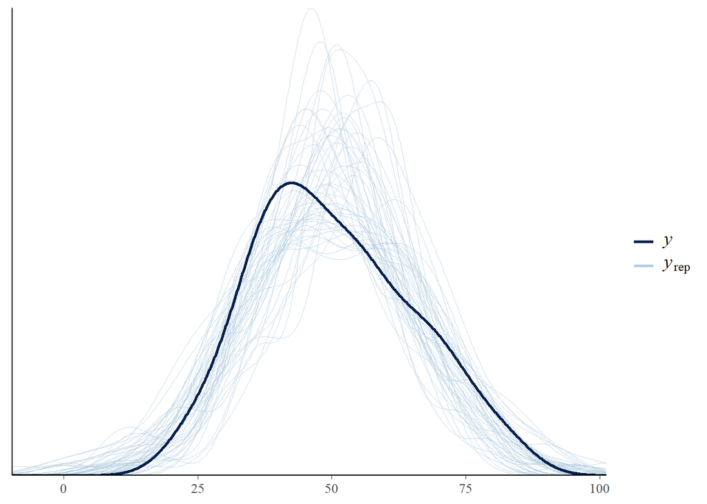

```r
pp_check(model_1)
```

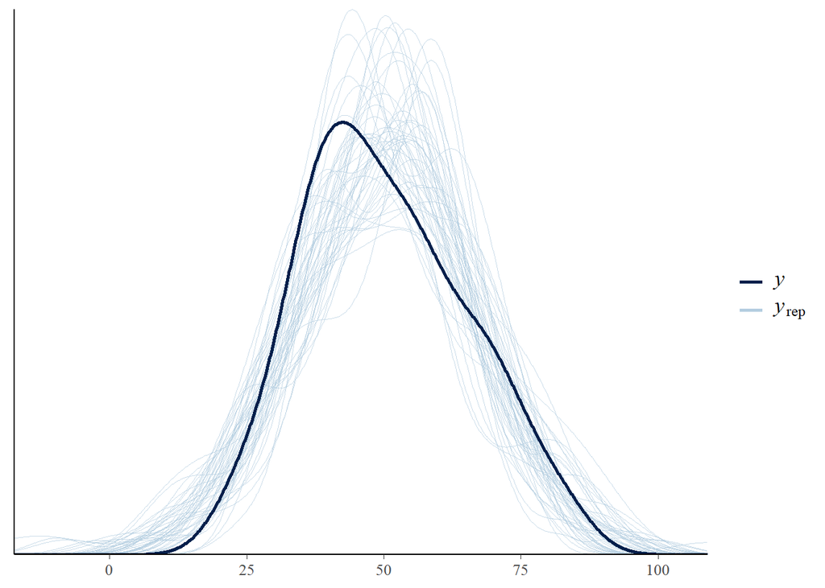

```r
pp_check(model_2)
```

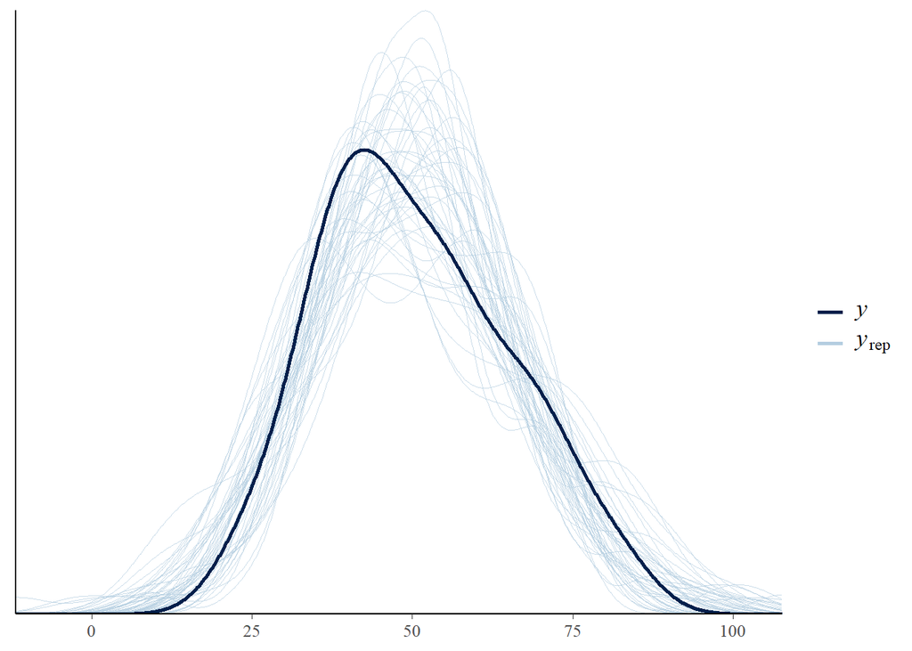

```r
pp_check(model_3)
```

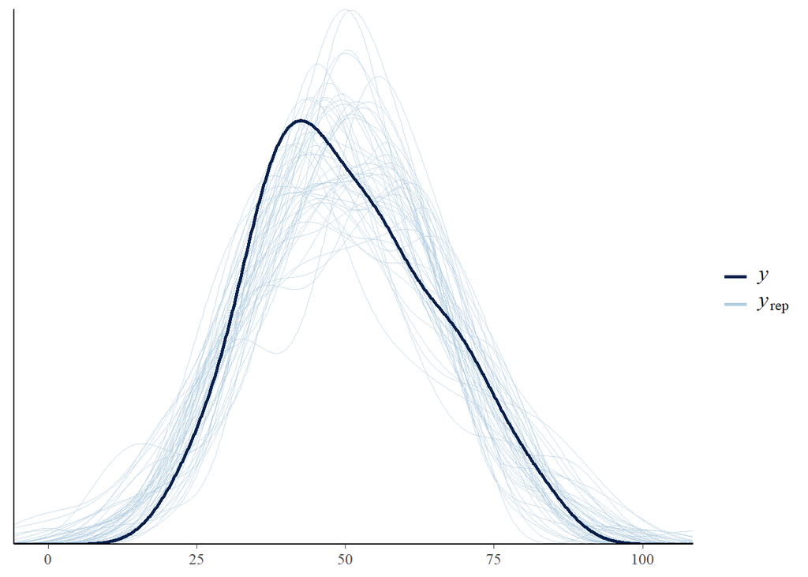

```r
pp_check(model_4)
```

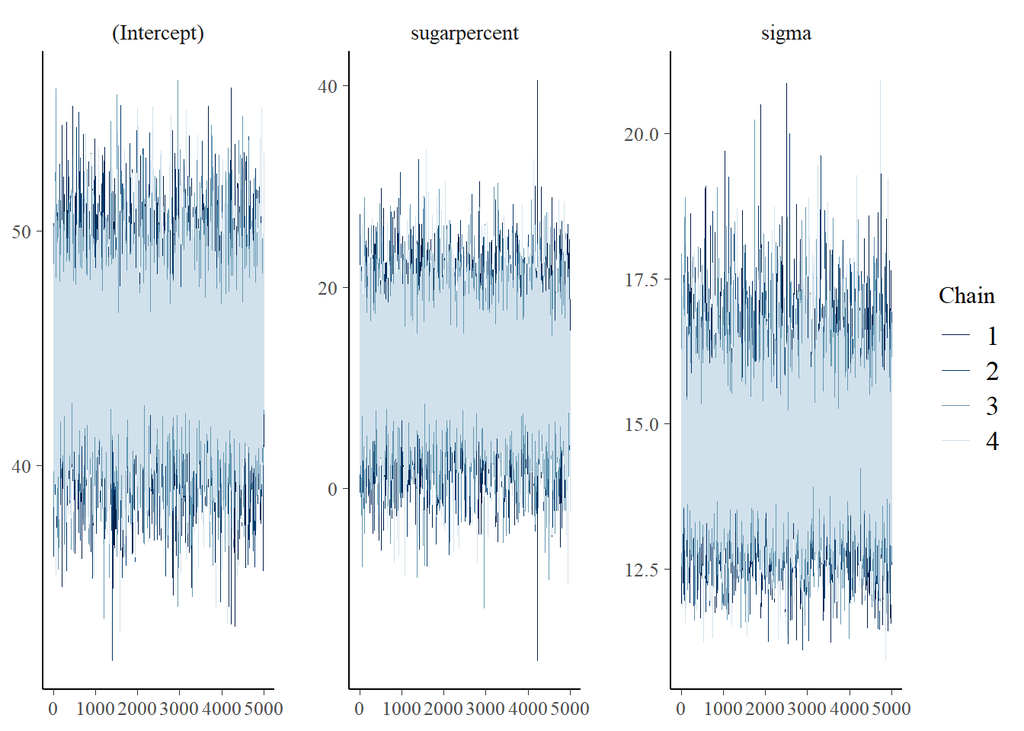

```r
mcmc_trace(model_1)
```

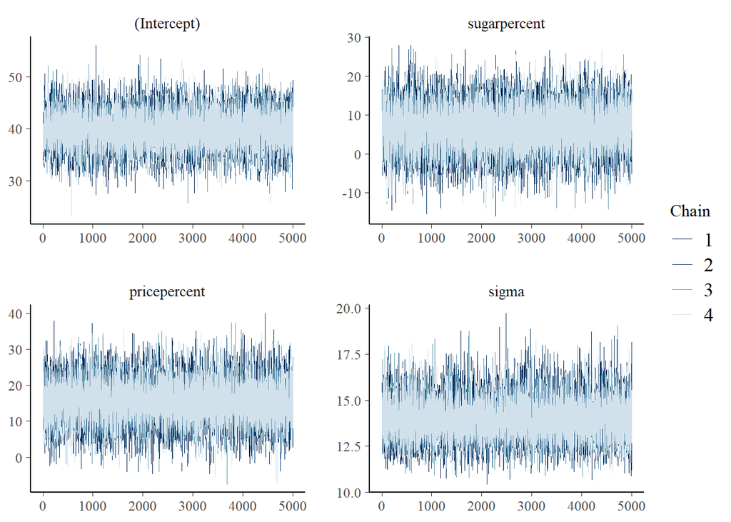

```r
mcmc_trace(model_2)
```

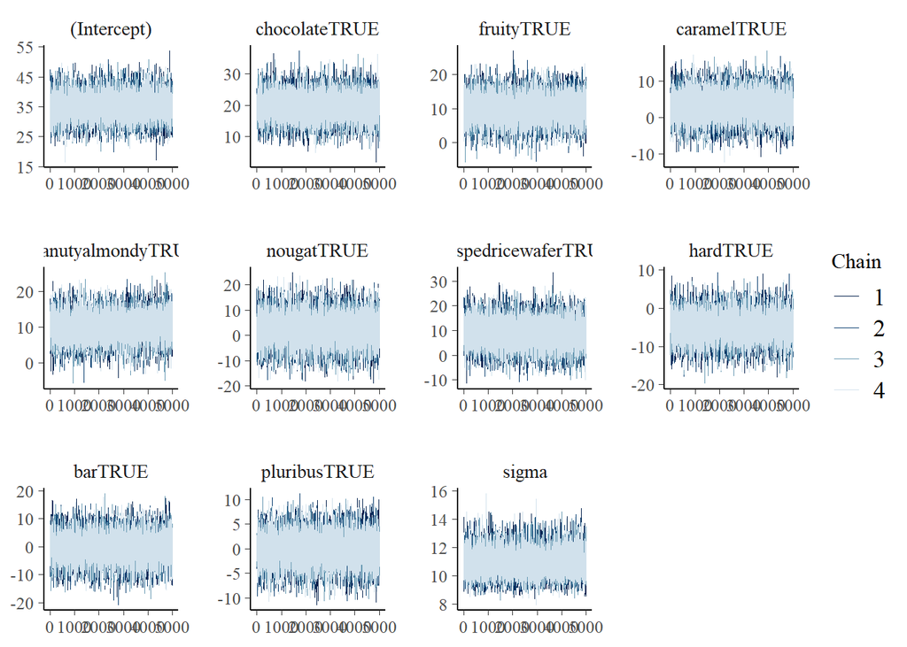

```r
mcmc_trace(model_3)
```

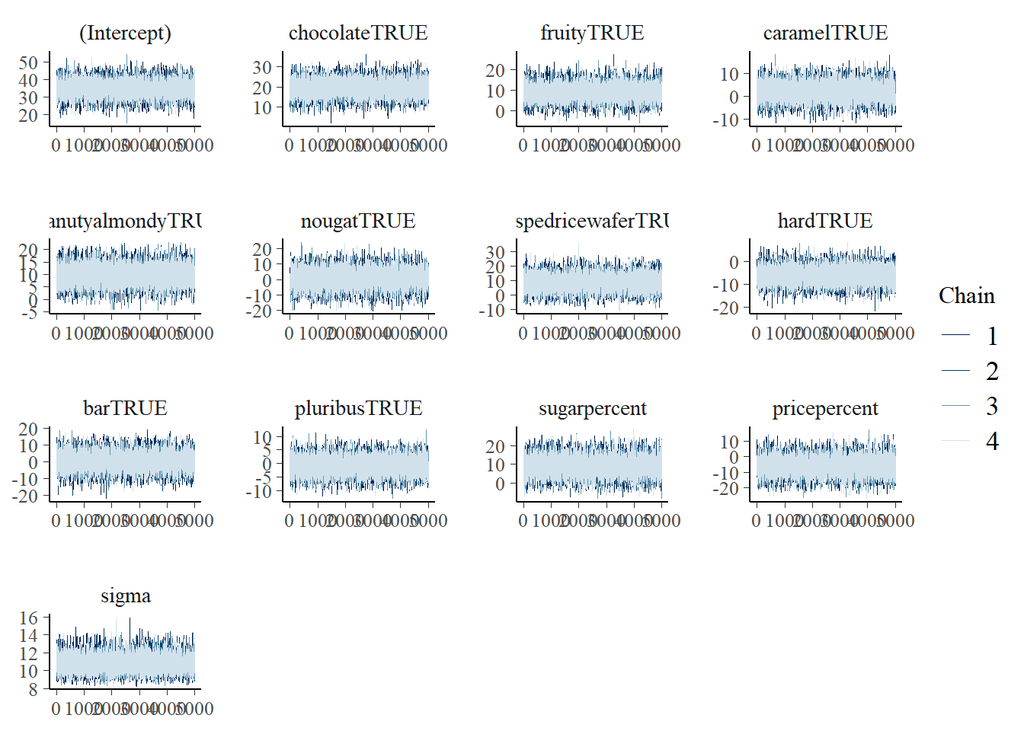

```r
mcmc_trace(model_4)
```

```r
# simulations are somewhat but not super stable. There are a few noticeable outliers in every model, as well as a relatively wide range of packed simulations. They seem to roughly fit, though go a little high overall.
```

Fragoso, T. M., W. Bertoli, and F. Louzada. 2018. “Bayesian Model Averaging: A Systematic Review and Conceptual Classification.” *International Statistical Review*. https://doi.org/10.1111/insr.12243.

Montgomery, Jacob, and Brendan Nyhan. 2010. “Bayesian Model Averaging: Theoretical Developments and Practical Applications.” *Political Analysis*.